# From zero to bioinformatics in R

Jonathan Dreyfuss PhD, Assoc Dir, Bioinfo & Biostat Core, Joslin Diabetes Center

2019-08-19

# Welcome

You’d like to analyze and visualize your data. Your workflow will be the most flexible, powerful, and reproducible if it involves *programming*. This type of programming is now called *data science*, and it’s one of the best jobs for the last several years according to [glassdoor](https://www.glassdoor.com/List/Best-Jobs-in-America-LST_KQ0,20.htm).

# Goal of tutorial

Programming looks intimidating, but once you understand the basics, you should be able to Google questions, understand the answers, and be productive. I’ll try to teach as much of the basics as I can in the hour I have to present this tutorial. You may wish to come back to it later to refresh and practice.

# R

- R is a free language and software for statistical computing and graphics
- R has thousands of free contributed packages, such as roughly 1000 bioinformatics packages that make up the [Bioconductor](https://www.bioconductor.org/) project, and packages that allow R to create data-rich, interactive [websites](https://shiny.rstudio.com/gallery/)
- You can download base R for [Windows](https://cloud.r-project.org/bin/windows/base/) or [Mac OS X](https://cloud.r-project.org/bin/macosx/) or Linux

# RStudio

- [RStudio](https://www.rstudio.com/) is the most popular integrated development environment (IDE) for R
- We will be using R through RStudio
- You can download [RStudio Desktop: Open Source Licence](https://www.rstudio.com/products/rstudio/download/) for free
- RStudio has a lot of functionality, so it will take some time to become comfortable with

## Resources

In RStudio go to Help/R Help, then

- [Learning R Online](https://www.rstudio.com/online-learning/). One resource they cite is the free book [R for Data Science](https://r4ds.had.co.nz/), which has a particularly helpful chapter on [data visualization](https://r4ds.had.co.nz/data-visualisation.html) using the popular R package `ggplot2`.
- *An Introduction to R*. The intro is also available in [PDF](http://cran.r-project.org/doc/manuals/R-intro.pdf). I found it (especially the first six chapters, which is only 30 pages) very helpful when I was learning R.
- RStudio also maintains many [cheatsheets](https://www.rstudio.com/resources/cheatsheets/), including an introductory cheatshet for Base R – this cheatsheet has much of what we will cover.

Harvard R/bioinformatics [trainings](http://bioinformatics.sph.harvard.edu/training/)

## R packages developed by the Core

Dr. Hui Pan (Bioinfo & Biostat Core) and I have developed several R packages to streamline bioinformatics analysis. These are based on the popular R package [limma](https://www.ncbi.nlm.nih.gov/pmc/articles/PMC4402510/), which applies linear regression modeling of omics data with sophisticated variance estimation to improve power, and has been validated multiple times. Our packages are freely available on the popular code repository [Github](https://github.com/). R packages on Github can be directly installed in R.

Our analysis package is ezlimma and our plotting package is ezlimmaplot, whose README includes installation instructions for both.

## R Markdown

This HTML report is written in [R Markdown](https://rmarkdown.rstudio.com/), which weaves together text, figures, and code. You can “Knit” R Markdown documents into HTML, PDF, Microsoft Word, or other formats by pressing the “Knit” icon in R Studio. (This requires you to install the “knitr” package and the packages used below, “ezlimma” and “ezlimmaplot”.)

[figure not shown]

Image from [RStudio R Markdown lesson](https://rmarkdown.rstudio.com/lesson-9.html)

```r
install.packages("knitr", repos = "https://cloud.r-project.org")
```

## RStudio panels

The R Markdown is in the *Source* panel. This is where you write & save your code. The *Console* is below; it executes R code. We’ll look at the other panels soon.

Press ctrl+enter (or cmd+enter on a mac) to send a line or highlighted portion to console. When a line is executed, its return value is displayed unless that value is assigned to a variable.

```r
1+1
```

```
## [1] 2
```

```r
# is a comment. it doesn't get executed.
x <- 1+1 #nothing is displayed
```

# Types

## Numeric

```r
x <- 4 #assigns the value 4 to variable x. '<-' represents an arrow.
x = 4 #does the same thing.  '<-' is usually equivalent to '='.
print(x) #you can also see the value in the Environment tab in the upper right
```

```
## [1] 4
```

```r
x #same as print() when not in loop or function
```

```
## [1] 4
```

```r
x+2
```

```
## [1] 6
```

```r
sum(x, 2) #same as x+2
```

```
## [1] 6
```

However, R is case sensitive, so this produces an error

```r
X+2 #Error: object 'X' not found
```

## Logicals

A logical can have the values `TRUE`, `FALSE`, and `NA` (“Not Available”). You might see `TRUE` and `FALSE` abbreviated as `T` and `F`, respectively, but I don’t recommend using the abbreviation. You can create logicals with: `<`, `<=`, `>`, `>=`, `==` for equality, `!=` for inequality. Logical operators are: `!` for *not*; `&` for *and*; `|` for *or*.

```r
4==4 #is 4 equal to 4?
```

```
## [1] TRUE
```

```r
4!=5 #is 4 not equal to 5?
```

```
## [1] TRUE
```

```r
x <- 4 > 5 #assign the value of 4>5 (i.e. FALSE) to x
!x #not x
```

```
## [1] TRUE
```

```r
x | (5>4)
```

```
## [1] TRUE
```

```r
x & TRUE
```

```
## [1] FALSE
```

An easy mistake is to check equality with `=`.

```r
4=4 #doesn't work, '=' is for assigning values to variables
```

We use logicals in `if` statements.

```r
z <- 3
if (z==3){
  print('z is 3')
}
```

```
## [1] "z is 3"
```

We can also add an action if our condition is `FALSE`.

```r
if (z==4){
  print('z is 4')
} else {
  print('z is not 4')
}
```

```
## [1] "z is not 4"
```

## Characters

```r
x <- 'hello' #a character string
x <- "hello" #same as above, can use single or double quotes
```

Can paste character strings together

```r
paste(x, 'world')
```

```
## [1] "hello world"
```

## `NA` (*Not Available*) values

This is for missing data. `NA`s can occur in any variable type and are treated specially.

```r
y <- NA #data for y is missing
y+1 #don't know y, so the result is also missing
```

```
## [1] NA
```

```r
is.na(y) #test if a value is NA
```

```
## [1] TRUE
```

```r
sum(y, 1, na.rm=TRUE) #ignore NAs in sum
```

```
## [1] 1
```

## Getting help

To get help on `sum()` function, can Google: “r sum” or “sum in r”. If you know the function name, you can search R Studio’s *Help* tab in the bottom right panel with:

```r
?sum
```

## Change types, called *coercion*

Functions sometimes need input to be of a particular type, e.g. can coerce numbers to character.

```r
as.character(z) #can tell it's a character because it's now in quotes
```

```
## [1] "3"
```

```r
#or logical to numeric
as.numeric(TRUE) #1
```

```
## [1] 1
```

```r
as.numeric(FALSE) #0
```

```
## [1] 0
```

# Vectors

We want a variable to be able to hold more than a single value. A vector is a list of values of a common type (e.g. numbers). We can do similar operations as above to multiple values in a vector simultaneously.

## Numeric vectors

```r
x <- c(1, 2, 3, 4) #c() is concatenation -- it creates a vector
x
```

```
## [1] 1 2 3 4
```

We can also use `:` to create a continuous sequence

```r
x <- 1:4
x
```

```
## [1] 1 2 3 4
```

### Practice using functions

A more general way than `:` to create sequences is `seq()` function. Can learn about this with

```r
?seq
```

The following calls are the same

```r
seq(1,4,1)
```

```
## [1] 1 2 3 4
```

```r
#R expects arguments in the given order, but you can name them & give in any order
seq(to=4, from=1, by=1)
```

```
## [1] 1 2 3 4
```

```r
#You don't always need to write out full argument names
#it matches "fr" to argument "from", since no other arguments start w/ "fr"
seq(to=4, fr=1, by=1)
```

```
## [1] 1 2 3 4
```

```r
#You don't need to specify arguments that already have the proper default
seq(to=4, by=1) #since default for from=1
```

```
## [1] 1 2 3 4
```

### Operations on numeric vectors

```r
y <- 2*x+1 #operates on each element of x
y
```

```
## [1] 3 5 7 9
```

```r
mean(x)
```

```
## [1] 2.5
```

```r
length(x) #length of vector
```

```
## [1] 4
```

```r
var(x) #variance
```

```
## [1] 1.666667
```

```r
t.test(x, y)
```

```
##
##  Welch Two Sample t-test
##
## data:  x and y
## t = -2.4249, df = 4.4118, p-value = 0.06646
## alternative hypothesis: true difference in means is not equal to 0
## 95 percent confidence interval:
##  -7.3641672  0.3641672
## sample estimates:
## mean of x mean of y
##       2.5       6.0
```

```r
#we can repeat values using rep()
rep(x, times=2)
```

```
## [1] 1 2 3 4 1 2 3 4
```

```r
rep(x, each=2)
```

```
## [1] 1 1 2 2 3 3 4 4
```

## Logical vectors

```r
b1 <- y > 6 #is each element of y greater than 6?
b2 <- y == 7 #is each element of y equal to 7?
b1 & b2 #and
```

```
## [1] FALSE FALSE  TRUE FALSE
```

```r
b1 | b2 #or
```

```
## [1] FALSE FALSE  TRUE  TRUE
```

```r
!b1 #not
```

```
## [1]  TRUE  TRUE FALSE FALSE
```

```r
#which values are TRUE?
which(b1)
```

```
## [1] 3 4
```

```r
#some functions automatically coerce logicals to numeric
sum(b1)
```

```
## [1] 2
```

```r
mean(b1)
```

```
## [1] 0.5
```

## Character vectors

```r
first.names <- c('Frederick', 'Charles')
last.names <- c('Banting', 'Best')
#combine first & last names to make full names
paste(first.names, last.names)
```

```
## [1] "Frederick Banting" "Charles Best"
```

## Names

Elements of vectors can have names. We can create a vector with names using the concatenation function `c()`.

```r
x <- c(a=4, b=5, c=6)
x
```

```
## a b c
## 4 5 6
```

```r
names(x) #this is itself a vector
```

```
## [1] "a" "b" "c"
```

## Subset vectors

We can subset with square brackets using indices or names.

```r
#select 1st element
x[1]
```

```
## a
## 4
```

```r
x["a"]
```

```
## a
## 4
```

```r
#can select 2nd & 3rd element in multiple ways
x[2:3]
```

```
## b c
## 5 6
```

```r
x[c(2,3)]
```

```
## b c
## 5 6
```

```r
x[c("b", "c")]
```

```
## b c
## 5 6
```

```r
x[c(FALSE, TRUE, TRUE)]
```

```
## b c
## 5 6
```

```r
x[-1] #all elements except the 1st
```

```
## b c
## 5 6
```

# Matrices & Data frames

Matrix is a table of elements of a common type.

```r
m <- matrix(1:4, ncol=2, nrow=2) #create a numeric matrix
m #can also click on "m" in upper right panel, Environment tab
```

```
##      [,1] [,2]
## [1,]    1    3
## [2,]    2    4
```

```r
2*m+1 #operates on each element
```

```
##      [,1] [,2]
## [1,]    3    7
## [2,]    5    9
```

```r
m <- matrix(c('a', 'b', 'c', 'd'), ncol=2, nrow=2) #create a character matrix
#can also create by column-binding using cbind() or row-binding using rbind()
m <- cbind(first.names, last.names)
```

## Matrices can have rownames & colnames

```r
colnames(m)
```

```
## [1] "first.names" "last.names"
```

```r
rownames(m)
```

[output not shown]

```r
rownames(m) <- c("FB", "CB")
m
```

```
##    first.names last.names
## FB "Frederick" "Banting"
## CB "Charles"   "Best"
```

We can subset matrices & data frames using `object[rows, columns]`. As with vectors, we can specify these using indices or names.

```r
m[1,] #1st row; leaving the columns index empty selects all columns
```

```
## first.names  last.names
## "Frederick"   "Banting"
```

```r
m['FB',] #1st row
```

```
## first.names  last.names
## "Frederick"   "Banting"
```

```r
m[,1] #1st column
```

```
##          FB          CB
## "Frederick"   "Charles"
```

```r
m[,'first.names'] #1st column
```

```
##          FB          CB
## "Frederick"   "Charles"
```

```r
m[2,1] #2nd row, 1st column
```

```
## [1] "Charles"
```

## Data frames

A data frame is a table where columns can be of different types but elements within a column are of a common type, like a vector. This is the type of table you’ll likely use most of the time.

### `data.frame`

Can create data frame using `data.frame`

```r
d <- data.frame(first.names, last.names, num=1:2)
colnames(d)
```

```
## [1] "first.names" "last.names"  "num"
```

```r
rownames(d) <- c("FB", "CB")
d[c("FB", "CB"), 2]
```

```
## [1] "Banting" "Best"
```

```r
d[,c('first.names', 'num')]
```

```
##    first.names num
## FB   Frederick   1
## CB     Charles   2
```

```r
#can also use $ for data frame columns
d$first.names
```

```
## [1] "Frederick" "Charles"
```

# Object info

Can get detailed info about objects with `summary()` or `str()`

```r
summary(d)
```

```
##  first.names         last.names             num
##  Length:2           Length:2           Min.   :1.00
##  Class :character   Class :character   1st Qu.:1.25
##  Mode  :character   Mode  :character   Median :1.50
##                                        Mean   :1.50
##                                        3rd Qu.:1.75
##                                        Max.   :2.00
```

```r
str(d) #shows structure
```

```
## 'data.frame':    2 obs. of  3 variables:
##  $ first.names: chr  "Frederick" "Charles"
##  $ last.names : chr  "Banting" "Best"
##  $ num        : int  1 2
```

# Factors

```r
#we can coerce factors to character
d[,1] <- as.character(d[,1])
str(d) #1st column is now character
```

```
## 'data.frame':    2 obs. of  3 variables:
##  $ first.names: chr  "Frederick" "Charles"
##  $ last.names : chr  "Banting" "Best"
##  $ num        : int  1 2
```

We can also prevent R from turning characters into factors by setting a global option

```r
options(stringsAsFactors=FALSE) #applies to the rest of your session
d2 <- data.frame(first.names, last.names, num=1:2)
str(d2) #no factors
```

```
## 'data.frame':    2 obs. of  3 variables:
##  $ first.names: chr  "Frederick" "Charles"
##  $ last.names : chr  "Banting" "Best"
##  $ num        : int  1 2
```

# Lists

Lists are arbitrary collections of objects. The elements don’t have to form a rectangular table or be of a common type. Lists can also be difficult to use, but you probably won’t use them directly much.

```r
l <- list(pathway1=c('gene1', 'gene2'), pathway2=c('gene3', 'gene4', 'gene5'))
l
```

```
## $pathway1
## [1] "gene1" "gene2"
##
## $pathway2
## [1] "gene3" "gene4" "gene5"
```

We can select using names with `$`, like columns of a data frame (a data frame is actually a list under the hood).

```r
l$pathway1
```

```
## [1] "gene1" "gene2"
```

Some functions return lists. For example, rownames and colnames of a matrix are together called dimnames, which is a list of length 2.

```r
dimnames(m)
```

```
## [[1]]
## [1] "FB" "CB"
##
## [[2]]
## [1] "first.names" "last.names"
```

```r
length(dimnames(m))
```

```
## [1] 2
```

Another function that returns a list is correlation with `cor.test()`.

```r
?cor.test #in documentation, "Value" section says it returns a list
```

```r
ct <- cor.test(1:3, c(6,5,7))
ct$p.value
```

```
## [1] 0.6666667
```

# Example data set

We’ll work with a simulated gene expression matrix, such as from a microarray, with 100 genes & 9 samples, split into 3 groups. We randomly simulate normally distributed values with `rnorm()`. We make the 1st gene up-regulated in group `a`.

We’re going to treat this data as being on the log2-scale and already *processed*. For many datasets, there are zeroes or missing values that might need to be imputed; samples need to be normalized to make them comparable and amenable to statistical tests; absent genes need to be removed; sample outliers need to be assessed to examine whether some experimental variables or batch effects need to be accounted for or the samples need to be removed or down-weighted; and trends between a gene’s mean expression and its variance should be accounted for, especially in RNA-seq data [voom](https://genomebiology.biomedcentral.com/articles/10.1186/gb-2014-15-2-r29).

```r
set.seed(0) #set a seed for random sampling to get reproducible results
gx <- matrix(rnorm(n=900), nrow=100, ncol=9)
#upregulate gene 1
gx[1, 1:3] <- gx[1, 1:3]+3
#sep='' says not to put a space between 'gene' and the numbers
rownames(gx) <- paste('gene', 1:100, sep='')
#3 samples in group 'a' & 3 in group 'b' & 3 in group 'c'
colnames(gx) <- c(paste('a', 1:3, sep=''), paste('b', 1:3, sep=''), paste('c', 1:3, sep=''))
```

We create matching phenotype & annotation data frames.

```r
pheno <- data.frame(grp=rep(c('a', 'b', 'c'), each=3))
rownames(pheno) <- colnames(gx)

# make random gene symbols: don't worry about how i generate these
annot <- data.frame(symbol=paste0(sample(x=LETTERS, size=100, replace=TRUE),
                                        sample(x=LETTERS, size=100, replace=TRUE),
                                        sample(x=LETTERS, size=100, replace=TRUE)),
                    pathway=sample(x=c("oxphos", "glycolysis", "tca cycle", "none"),
                                   size=nrow(gx), replace=TRUE))
rownames(annot) <- rownames(gx)
```

# Reading / writing data

We’re going to write & read from the working directory. R assumes by default that you’re reading/writing in your working directory.

```r
getwd() #see working directory
```

```
## [1] "B:/fcns/zero2bioinfo"
```

We can change working directory with `setwd()` or under Session/Set Working Directory. Usually we write to tab-delimited text (TXT) or comma separated value (CSV). Both can be opened in Excel, and Excel can save as both formats.

```r
write.csv(gx, "gx.csv") #now look in your working directory for the file
#tables are read in by default as data frames
gx <- read.csv("gx.csv", row.names=1) #row.names=1 sets 1st column as rownames
#transform gx from data.frame to a numeric matrix
gx <- data.matrix(gx)
```

# Many types of plots are available

Can see in R Studio in bottom right *Plots* tab

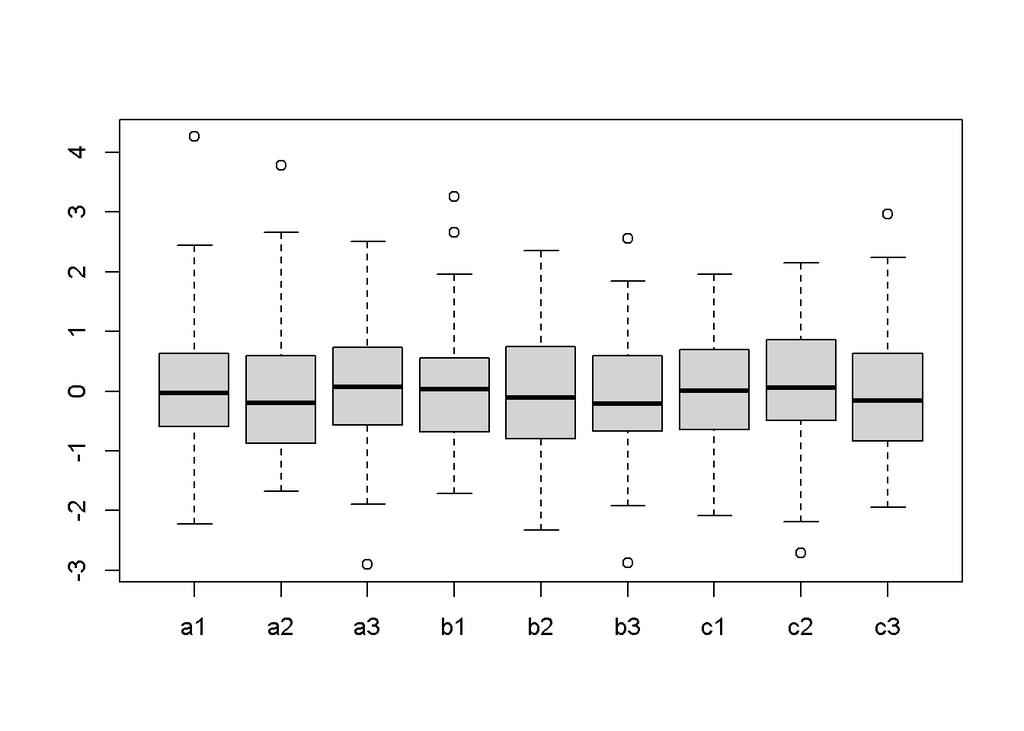

```r
boxplot(gx)
```

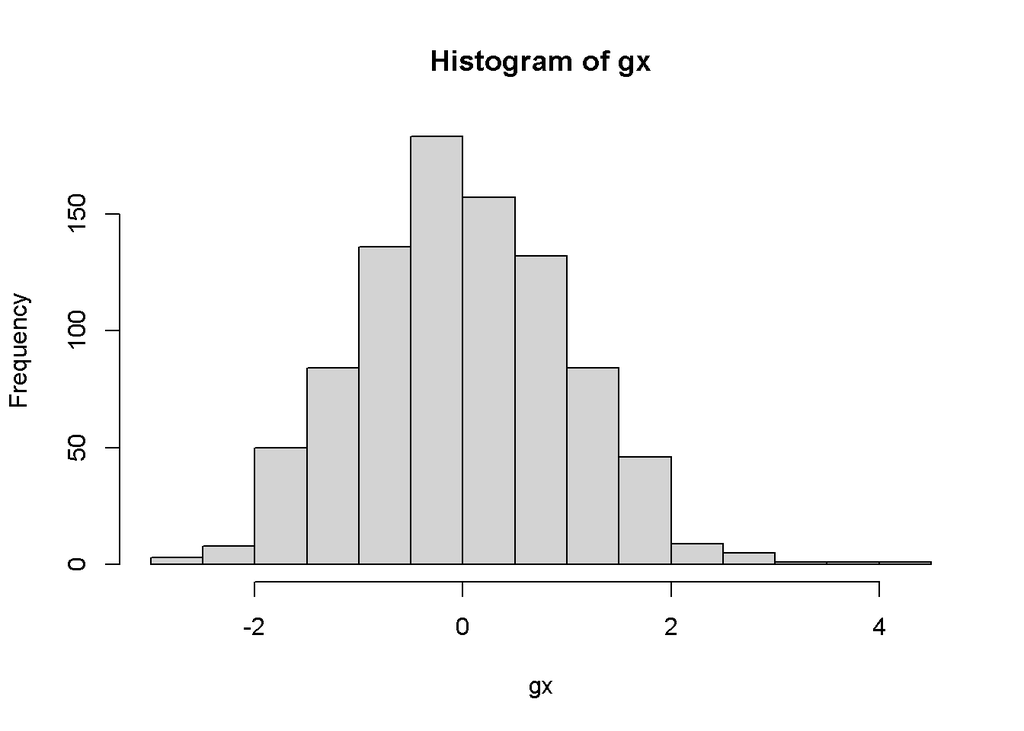

```r
hist(gx)
```

Most basic is `plot()` so we’ll practice with this.

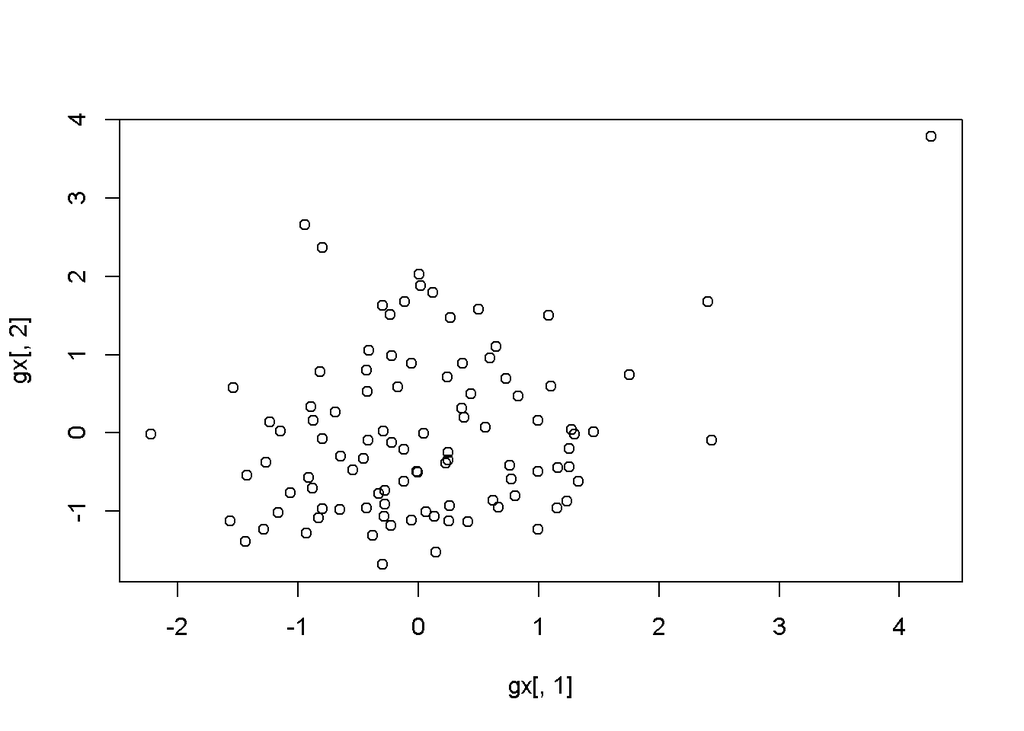

```r
plot(x=gx[,1], y=gx[,2]) #scatter plot of a1 vs a2
```

We want axis labels to be sample names. We find out how to do this by looking at

```r
?plot
```

We see that the arguments we need are:

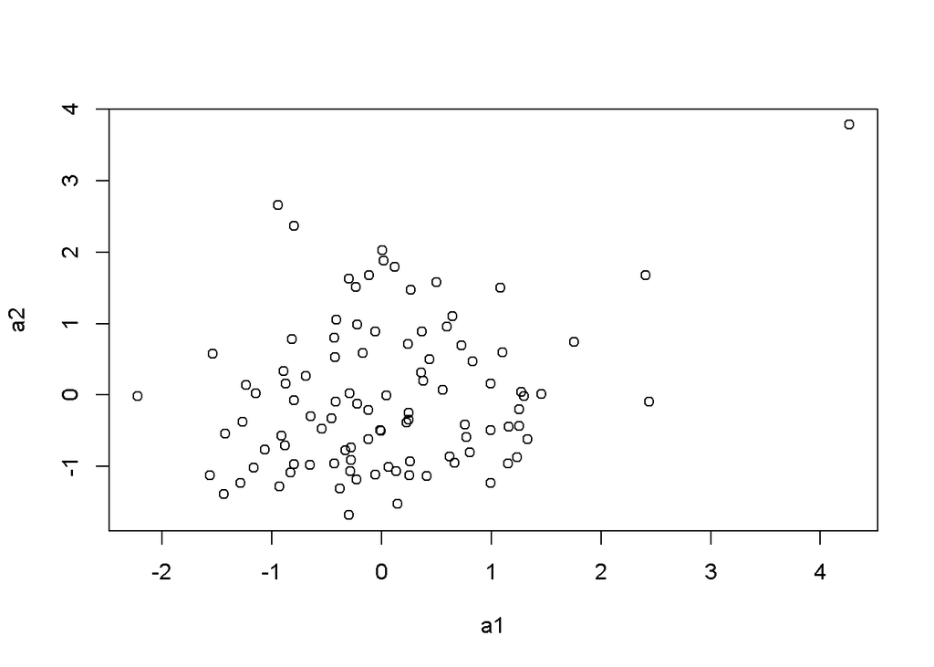

```r
plot(x=gx[,1], y=gx[,2], xlab=colnames(gx)[1], ylab=colnames(gx)[2])
```

We also want to reorient axis tick labels on y-axis.

```r
?plot #sends us to par. par options are applicable to many plots.
?par #there are many par options, the one we want is "las".
```

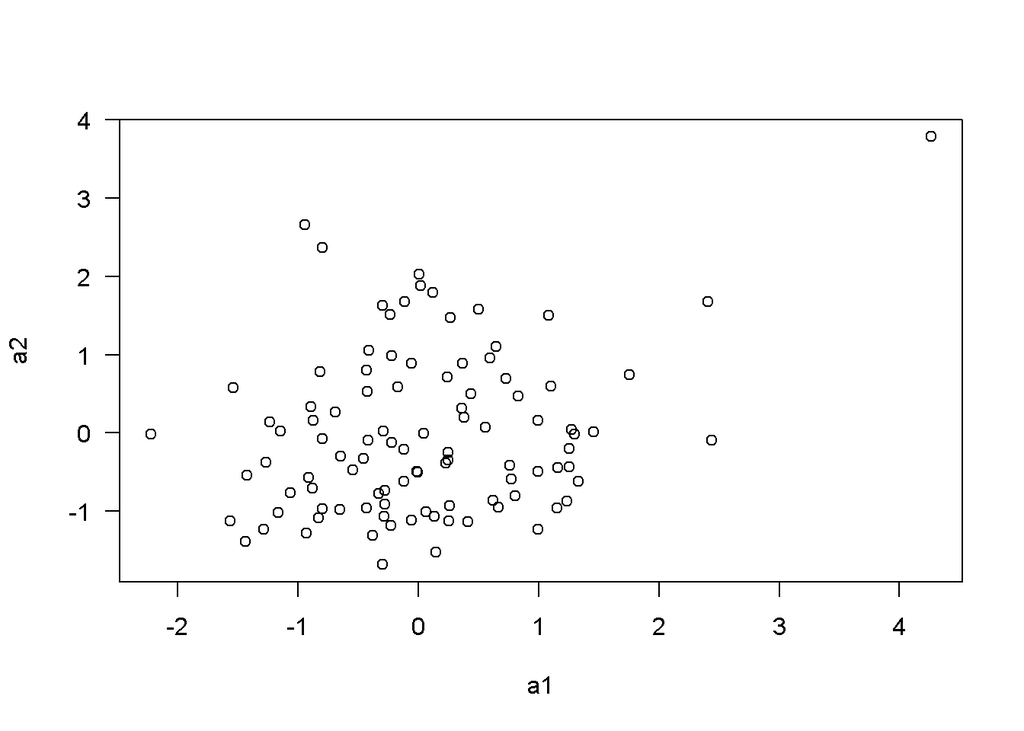

```r
plot(x=gx[,1], y=gx[,2], xlab=colnames(gx)[1], ylab=colnames(gx)[2], las=1)
```

## Save plot to file

We can use “Export” in *Plots* tab, or we can use code to open file, plot to it, then close it. We’ll make a PDF with `pdf` function but we could use `png`, `jpeg`, `tiff`, etc. Our PDF is at scatter.pdf.

```r
pdf("scatter.pdf") #open graphics device
plot(x=gx[,1], y=gx[,2], xlab=colnames(gx)[1], ylab=colnames(gx)[2], las=1)
dev.off() #close graphics device
```

## ggplot2

`ggplot2` is commonly used graphics package that makes pretty plots.

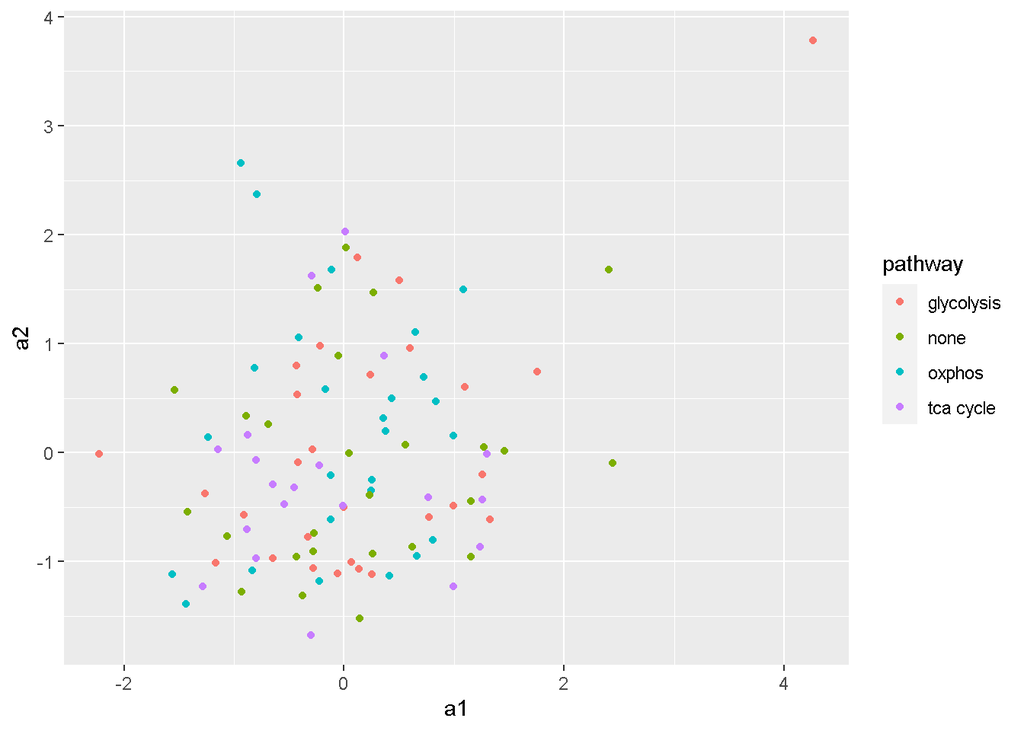

```r
library(ggplot2)
gx_df <- data.frame(gx, annot)
ggp <- ggplot(data = gx_df) + geom_point(mapping=aes(x=a1, y=a2, color=pathway))
ggp
```

```r
ggsave(filename = "gg_scatter.pdf", plot=ggp)
```

# Differential expression using base R (not add-on packages)

1. one gene at a time
2. `for` loop
3. `apply` function

## One gene at a time.

```r
t.test(gx[1, 1:3], gx[1, 4:6])$p.value #1st gene
```

```
## [1] 0.02976692
```

```r
t.test(gx[2, 1:3], gx[2, 4:6])$p.value #2nd gene
```

```
## [1] 0.5437477
```

## `for` loop

This can be automated using a `for` loop. We’ll create an empty vector of `NA`s & assign the t-test p-values to that vector. This loops the variable `gene` through each of the values between 1 & 100, and applies a t-test on that row.

```r
pv <- rep(NA, times=100)
for (gene in 1:100){
  pv[gene] <- t.test(gx[gene, 1:3], gx[gene, 4:6])$p.value
}
```

## `apply`

There’s a more advanced & faster way you `apply` the `t.test` function to each row.

```r
# MARGIN=1 says to apply to rows
pv <- apply(gx, MARGIN = 1, FUN=function(row.v){
  t.test(row.v[1:3], row.v[4:6])$p.value
})
```

# `ezlimma` package

You can install `ezlimma` by following instructions at ezlimma. `ezlimma`’s tutorial is presented as a *vignette*, like many R packages.

```r
library(ezlimma)
# browseVignettes(package="ezlimma")
```

Here we create multiple group comparisons, and test them all in one line with `limma_contrasts`.

```r
contrast.v <- c(AvsB='a-b', AvsC='a-c', BvsC='b-c')
toptab <- limma_contrasts(object=gx, grp=pheno$grp, contrast.v = contrast.v)
```

`toptab` is ordered by overall significance of the 3 tests. We round the number of significant digits in `toptab` to 3 with `signif`. When we add annotation, we make sure the rows of `toptab` match the rows of `annot` using `annot[rownames(toptab),]`. We write this to diff_gene_stats.csv.

```r
toptab.ann <- data.frame(signif(toptab, 3), annot[rownames(toptab),])
write.csv(toptab.ann, "diff_gene_stats.csv")
```

In `ezlimma`, we can also test correlation of each gene to a continuous phenotype in one line of code.

```r
Y <- c(1:9)
toptab.y <- ezcor(object = gx, phenotype = Y, prefix = "Y")
```

`toptab.y` is ordered by the significance of the correlation and gives correlation coefficient, p-value, and FDR.

We can plot the top gene, gene27, vs. `Y`.

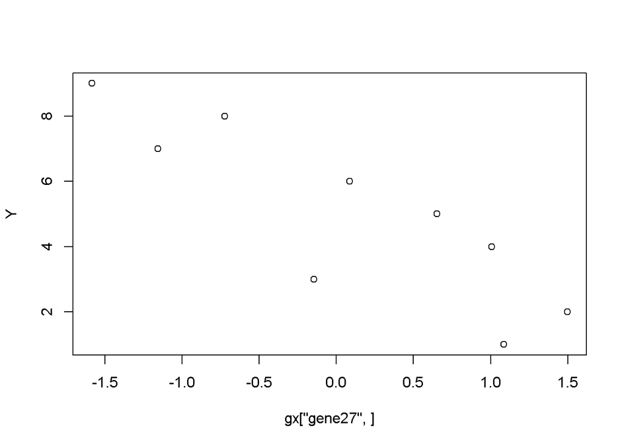

```r
plot(gx["gene27",], Y)
```

For pathway analysis, `ezlimma` extends `limma` `roast` to write linked Excel files, as explained in the `ezlimma` vignette.

# `ezlimmaplot` package

We can plot `ezlimma` results with `ezlimmaplot`. We’ll focus on the differential expression. You can install `ezlimmaplot` by following instructions at ezlimmaplot. `ezlimmaplot`’s tutorial is also presented as a *vignette*.

```r
library(ezlimmaplot)
# browseVignettes(package="ezlimmaplot")
```

## PCA

We make a Principal Component Analysis (PCA) plot to see how samples cluster. We use the `ezpca` function, which is based on the R package `ggplot2`. So `ezpca` doesn’t print to file, we set `name=NA` .

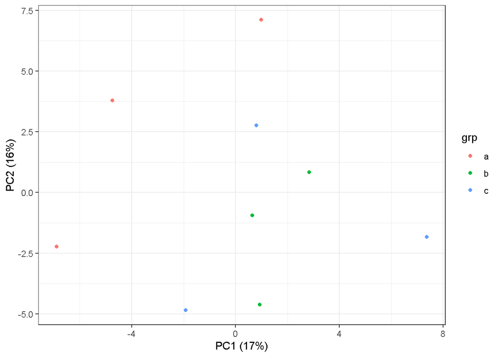

```r
ezpca(object=gx, pheno.df=pheno, name=NA, color="grp")
```

## Significance histograms

We make a histogram of p-values and false discovery rates (FDR) for each comparison, at signif_hist.pdf.

```r
signif_hist(tab = toptab)
```

## Venn diagram

We can see how many genes with p <= 0.05 the comparisons have in common.

```r
venn.tab <- ezvenn(tab=toptab, name=NA, p.cutoff = 0.05)
```

[figure not shown]

This plot doesn’t tell us which genes are in common, but `venn.tab` has this info, which we can view.

## Heatmap

We can make a heatmap of the top genes in `toptab.ann`.

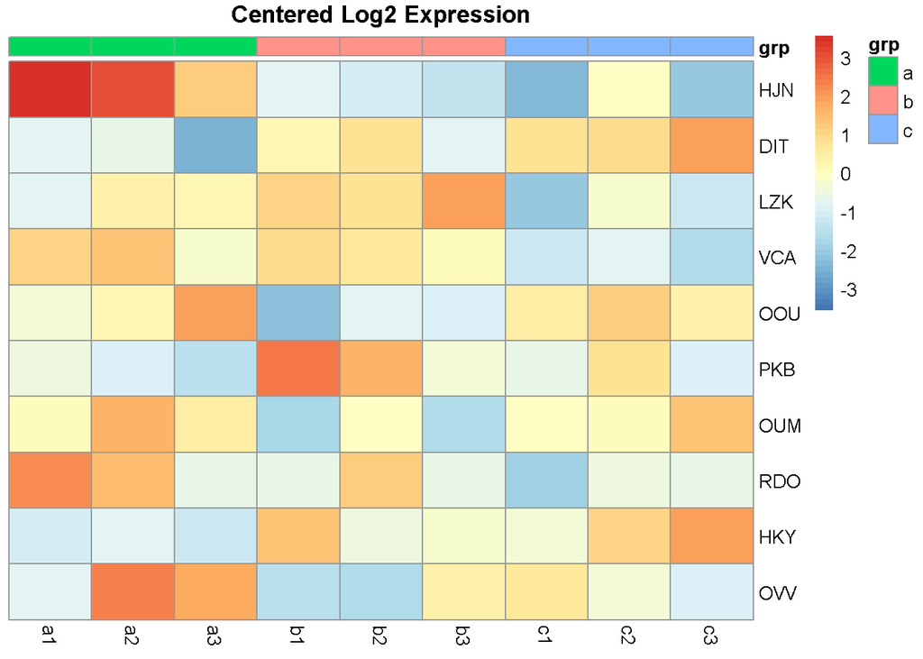

```r
top.genes <- rownames(toptab.ann)[1:10]
ezheat(object = gx[top.genes,], labrows=toptab.ann[top.genes, "symbol"], pheno.df = pheno, name=NA)
```

By default, the row scaling *centers* the rows by subtracting the row mean. Then the new mean of every row is zero. This helps see contrast between samples, instead of between rows.

## Volcano plot

We make a volcano plot for the 1st comparison, where we label the 3 most significant genes.

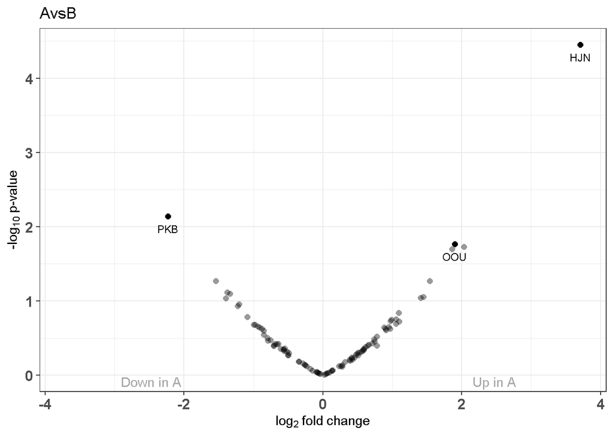

```r
ezvolcano(tab=toptab.ann, ntop.sig=3, lab.col="symbol", comparison = "AvsB", name=NA)
```

We can also make a volcano plot for all comparisons, volcanoes.pdf.

```r
multi_volcano(tab=toptab.ann, ntop.sig = 3, lab.col="symbol")
```

# Conclusion

Congratulations for making it this far. I hope this helped you become familiar enough with R so you can understand documentation, and hopefully analyze your data.